# ggplot2 : 8. Legends

```r
# install.packages(c('ggplot2’, 'gcookbook’), dependencies = TRUE)
library(ggplot2)
library(gcookbook)
```

## Removing the Legend

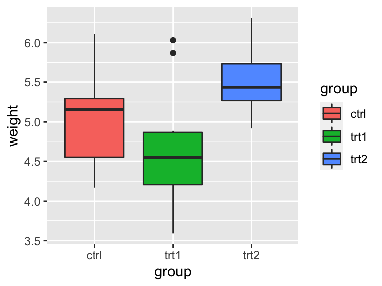

```r
p <- ggplot(PlantGrowth, aes(x = group, y = weight, fill = group)) + geom_boxplot()
p
```

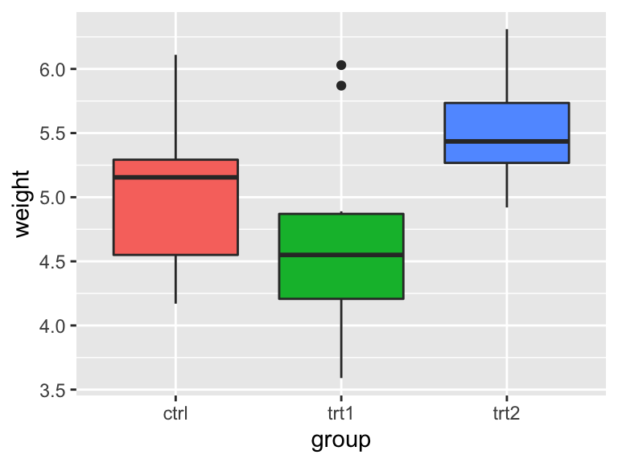

```r
p + guides(fill = FALSE)
```

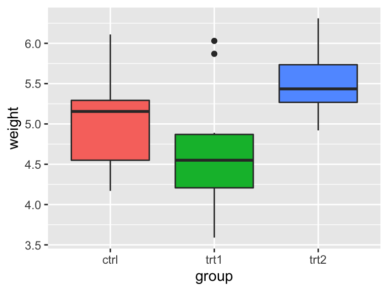

```r
p + scale_fill_discrete(guide = FALSE)
```

- `aes()`에서 `fill` 혹은 `color` 변수를 지정하게 되면 디폴트로 해당 구분을 위해 범례가 생성된다.
- 범례를 생성하지 않게 하기 위해서 `guides(fill = FALSE)` 혹은 `scale_fill_discrete(guide = FALSE)`를 함께 수행한다.
- color 변수로 인해 생성된 범례를 제거하기 위해서는 `guides(color = FALSE)` 혹은 `scale_color_discrete(guide = FALSE)`를 함께 수행한다.

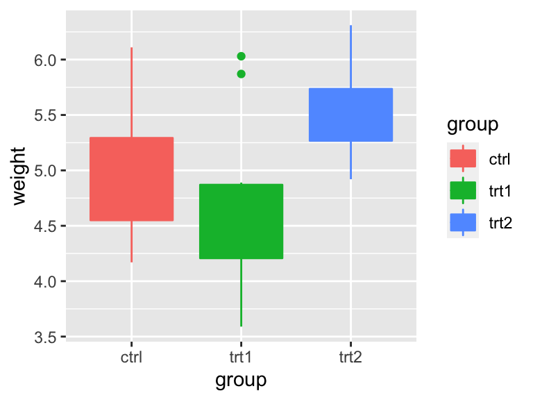

```r
p2 <-ggplot(PlantGrowth, aes(x = group, y = weight, fill = group, color = group)) +
  geom_boxplot()
p2
```

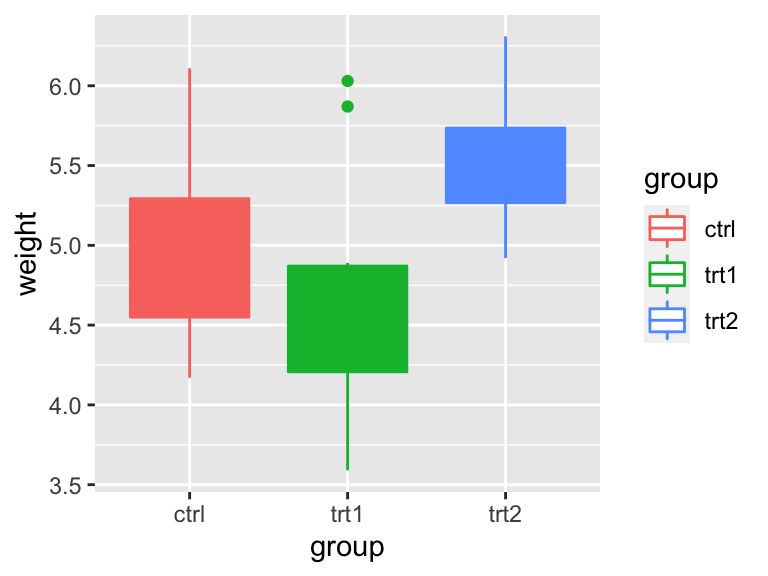

```r
p2 + guides(fill = FALSE)
```

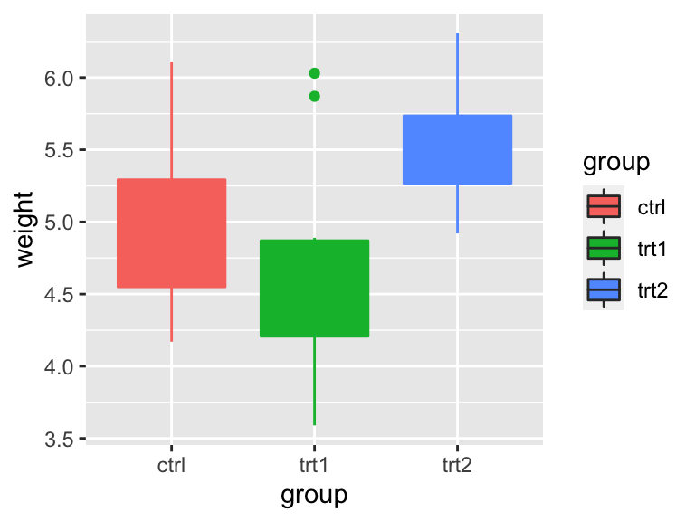

```r
p2 + guides(color = FALSE)
```

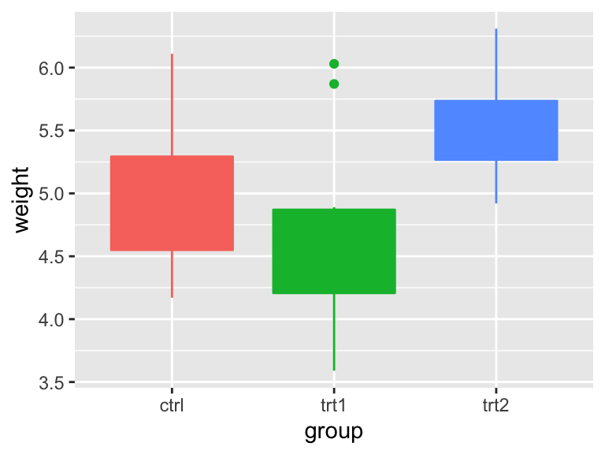

```r
p2 + guides(fill = FALSE, color = FALSE)
```

- `aes()`에서 `fill` 과 `color` 변수가 동시에 지정된 경우의 예.

## Changing the Position of a Legend

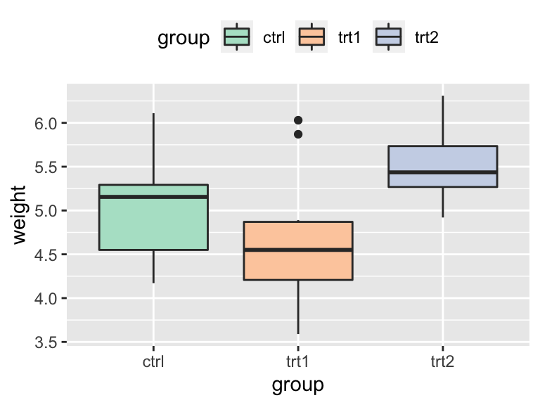

```r
p <- ggplot(PlantGrowth, aes(x = group, y = weight, fill = group)) + geom_boxplot() +
  scale_fill_brewer(palette = 'Pastel2')
p + theme(legend.position = 'top')
```

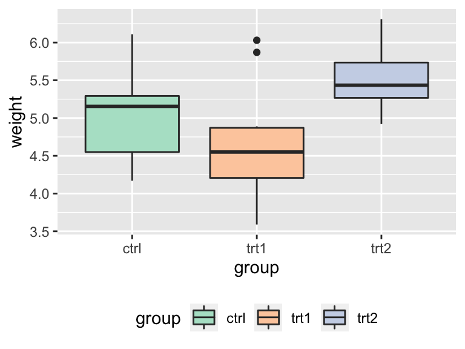

```r
p + theme(legend.position = 'bottom')
```

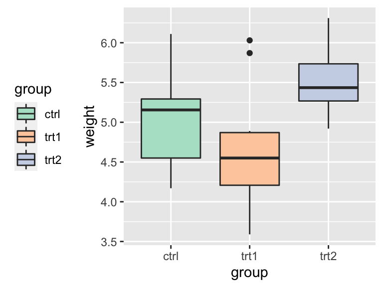

```r
p + theme(legend.position = 'left')
```

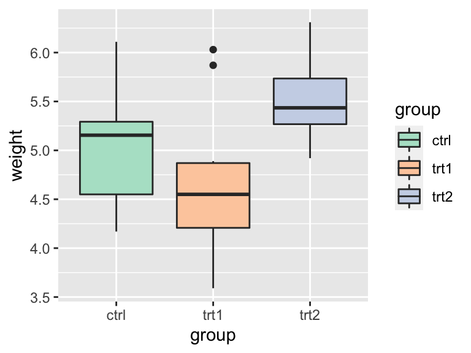

```r
p + theme(legend.position = 'right')
```

- 범례의 위치 변경의 예.

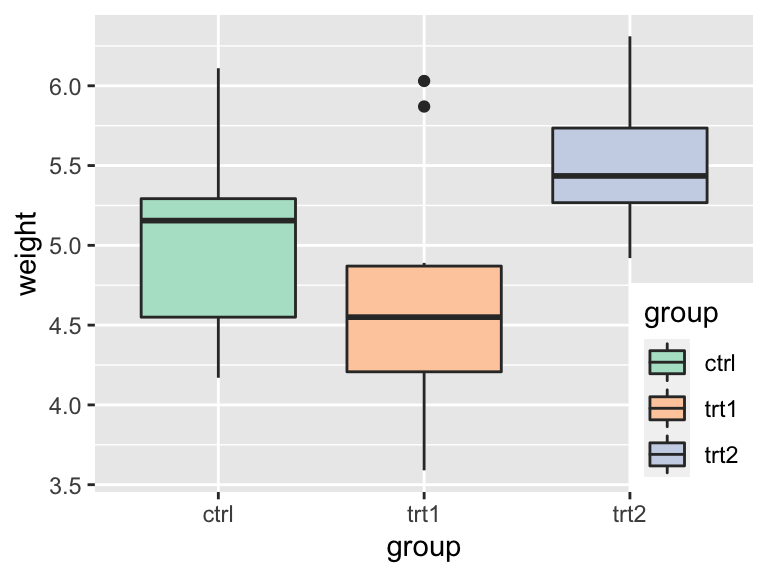

```r
p + theme(legend.position = c(1, 0), legend.justification = c(1, 0))
```

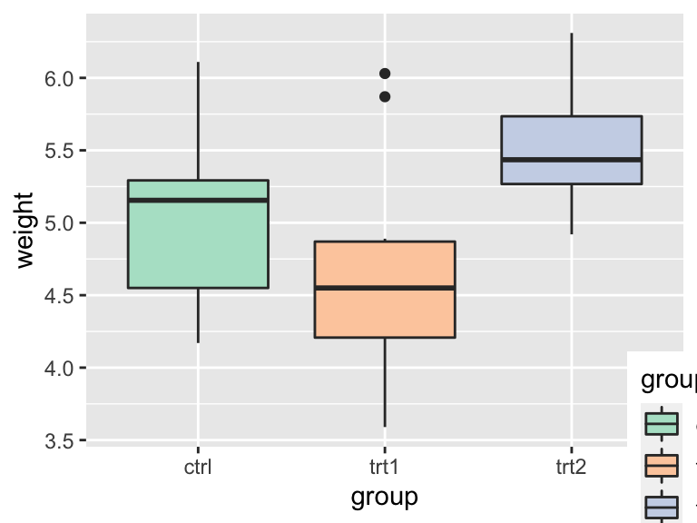

```r
p + theme(legend.position = c(1, 0), legend.justification = c(0.5, 0.5))
```

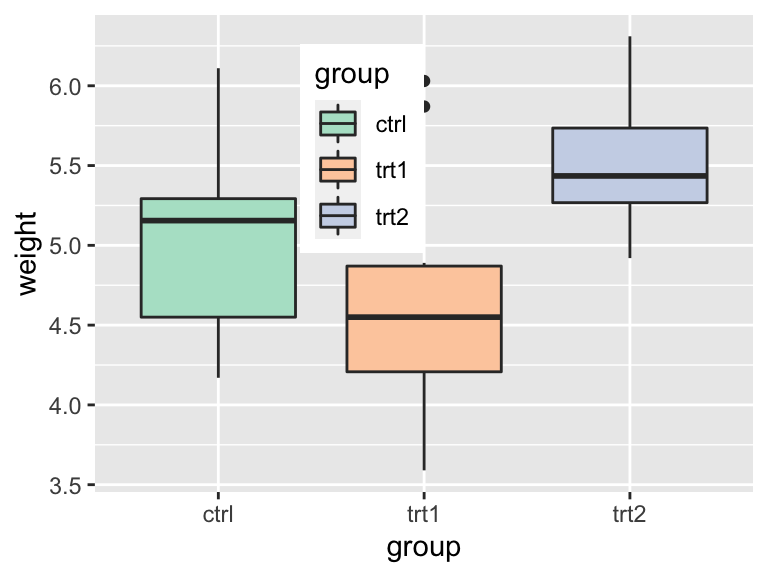

```r
p + theme(legend.position = c(0.5, 0.5), legend.justification = c(1, 0))
```

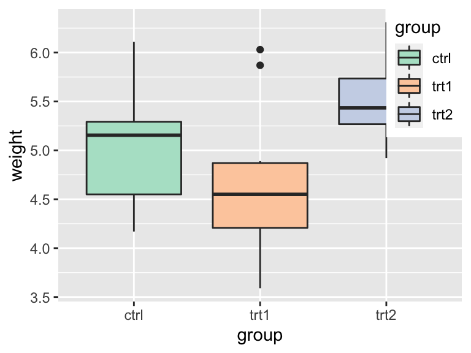

```r
p + theme(legend.position = c(1, 1), legend.justification = c(1, 1))
```

- 좌표를 지정을 통한 범례 위치를 그림 내부로 변경한 경우의 예.
- `legend.position = c(1, 0)` 을 이용하여 plotting area의 오른쪽 하단을 지정하고 `legend.justification = c(1, 0)` 을 이용하여 범례의 오른쪽 하단을 지정. 이 두 점을 맞추도록 범례를 위치.

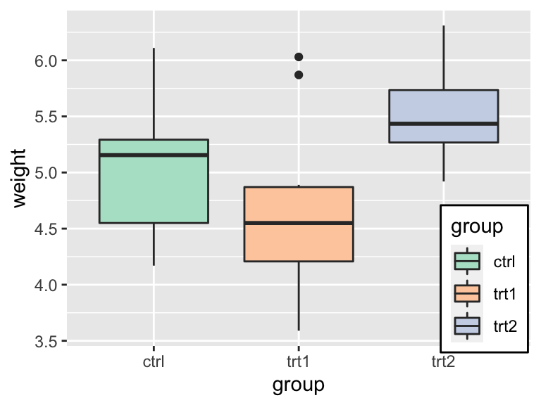

```r
p + theme(legend.position = c(0.9, 0.2)) +
  theme(legend.background = element_rect(fill = 'white', color = 'black'))
```

- 범례의 경계선 변경의 예.
- `legend.justification` 의 디폴트 위치는 c(0.5, 0.5) 임.

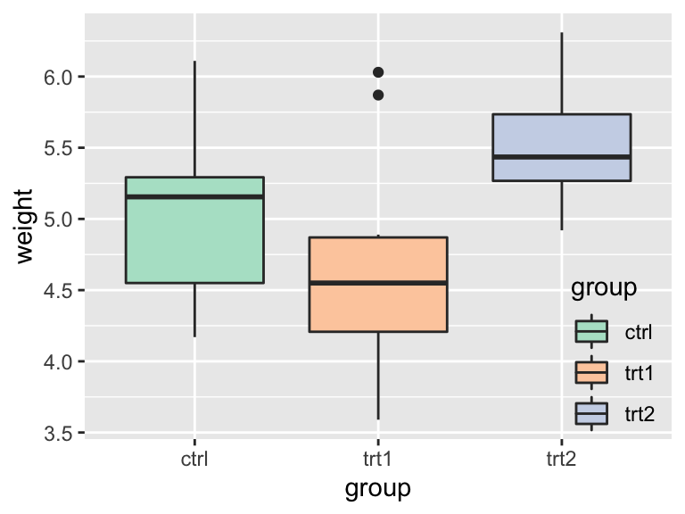

```r
p + theme(legend.position = c(0.9, 0.2)) +
  theme(legend.background = element_blank()) +  # remove overall border
  theme(legend.key = element_blank()) # remove border around each item
```

- 범례의 경계선 및 각 item의 경계선을 모두 투명하게 만든 예.

## Changing a Legend Title

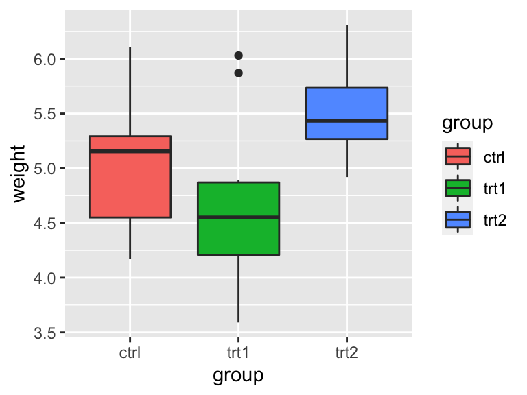

```r
p <- ggplot(PlantGrowth, aes(x = group, y = weight, fill = group)) + geom_boxplot()
p
```

```r
p + labs(fill = 'Condition')
```

[output not shown]

```r
p + scale_fill_discrete(name = 'Condition')
```

[output not shown]

```r
p + guides(fill = guide_legend(title = 'Condition'))
```

[output not shown]

- 범례 title 변경 방법의 예.
- `labs(fill = ‘Condition’)` : fill에 적용된 변수에 대한 타이틀을 변경.
- `scale_fill_discrete(name = ‘Condition’)` : 범주형 변수로 정의된 fill 변수의 이름을 변경.
- `guides(fill = guide_legend(title = ‘Condition’))` : 범례에 표시될 fill에 대응하는 범주를 주는 변수의 타이틀을 변경.
- 위의 세가지 방식 모두 같은 결과를 줌.

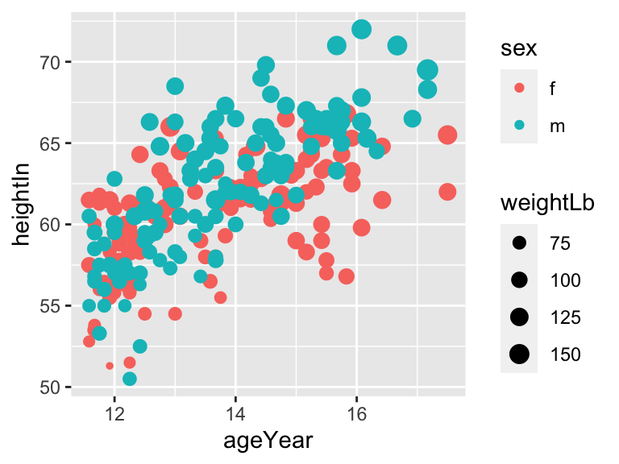

```r
hw <- ggplot(heightweight, aes(x = ageYear, y = heightIn, color = sex)) +
  geom_point(aes(size = weightLb)) + scale_size_continuous(range = c(1, 4))
hw
```

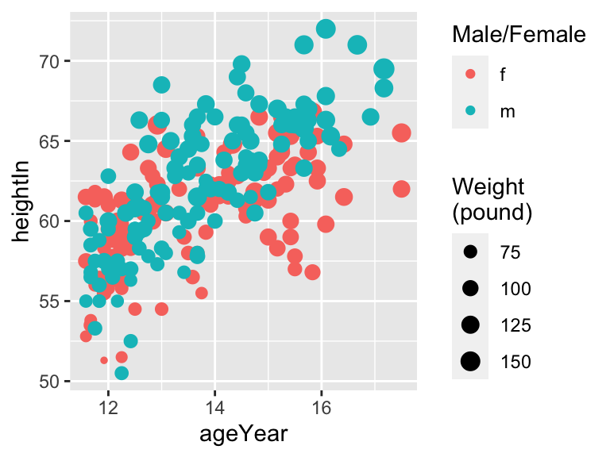

```r
hw + labs(color = 'Male/Female', size = 'Weight\n(pound)')
```

- color 변수 및 size 변수의 이름을 동시에 변경한 예.

## Changing the Appearance of a Legend Title

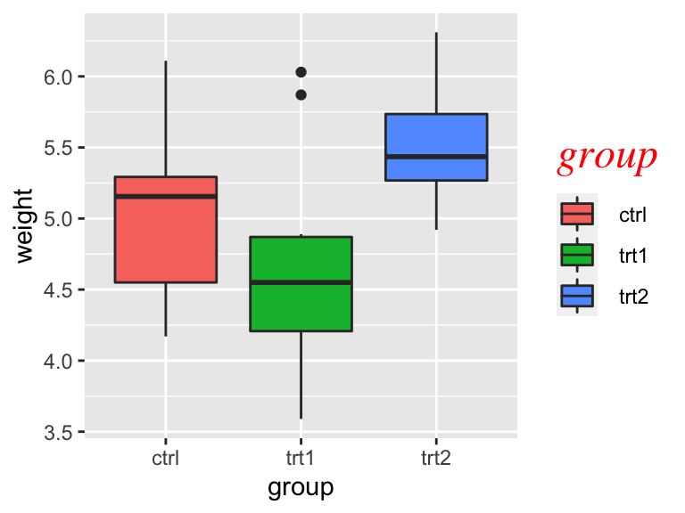

```r
p <- ggplot(PlantGrowth, aes(x = group, y = weight, fill = group)) + geom_boxplot()
p + theme(legend.title = element_text(face = 'italic', family = 'Times', color = 'red', size = 18))
```

- 범례 제목의 모양을 바꾼 예.

## Removing a Legend Title

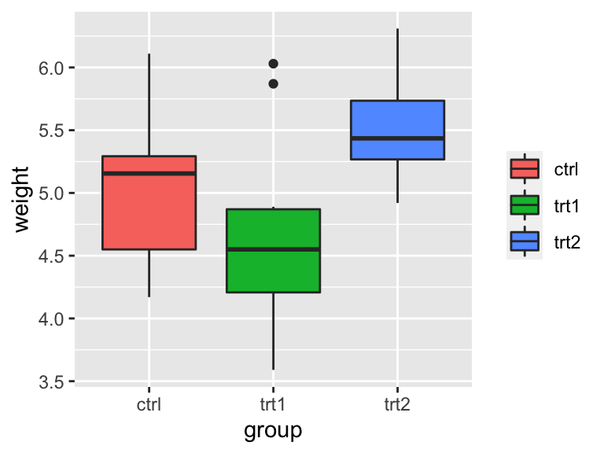

```r
ggplot(PlantGrowth, aes(x = group, y = weight, fill = group)) + geom_boxplot() +
  guides(fill = guide_legend(title = NULL))
```

- 범례 제목을 제거한 예.
- `guides(fill = guide_legend(title = NULL))` 은 `theme(legend.title = element_blank())` 와 동일한 결과를 줌.

## Chaning the Labels in a Legend

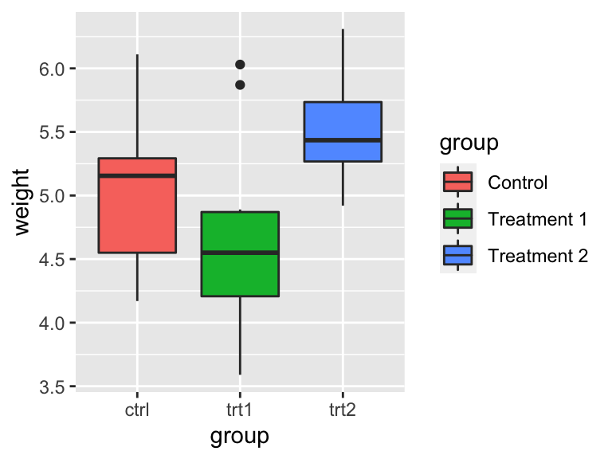

```r
p <- ggplot(PlantGrowth, aes(x = group, y = weight, fill = group)) +
    geom_boxplot()
p + scale_fill_discrete(labels = c('Control', 'Treatment 1', 'Treatment 2'))
```

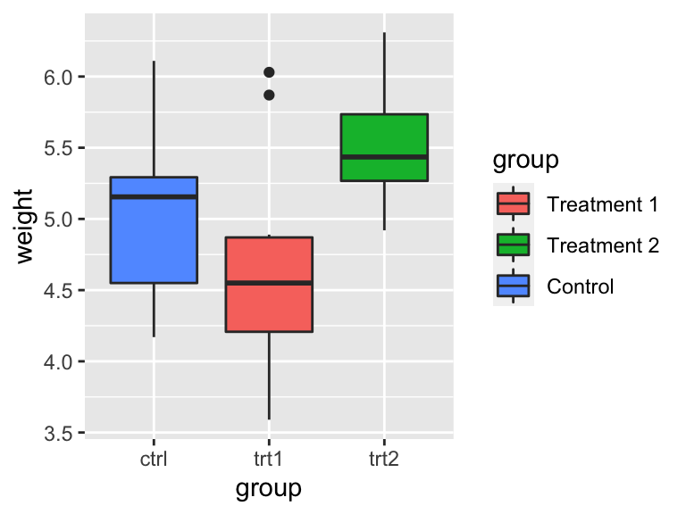

```r
# change the order of labels in a legend
p + scale_fill_discrete(limits = c('trt1', 'trt2', 'ctrl'),
                        labels = c('Treatment 1', 'Treatment 2', 'Control'))
```

- 범례에 이용된 변수(fill 변수)의 변수값에 대한 label을 바꿈.
- discrete (factor) 변수이므로 변수값의 label을 바꾸기 위해 `scale_fill_discrete()` 함수를 이용함.

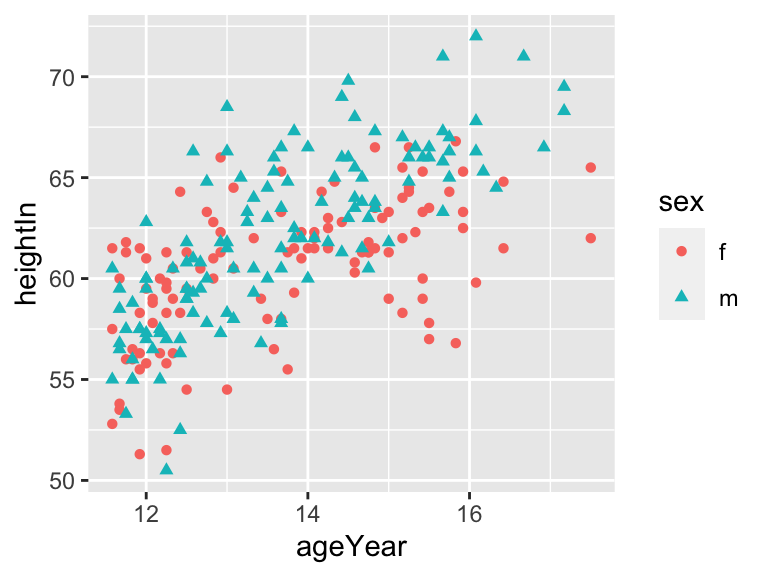

```r
p <- ggplot(heightweight, aes(x = ageYear, y = heightIn, shape = sex, color = sex)) +
  geom_point()
# see the difference
p
```

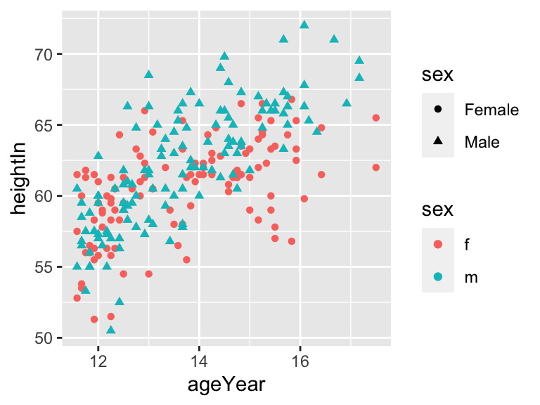

```r
p + scale_shape_discrete(labels = c('Female', 'Male'))
```

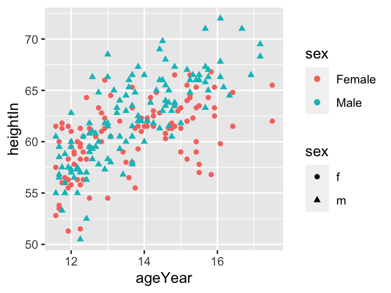

```r
p + scale_color_discrete(labels = c('Female', 'Male'))
```

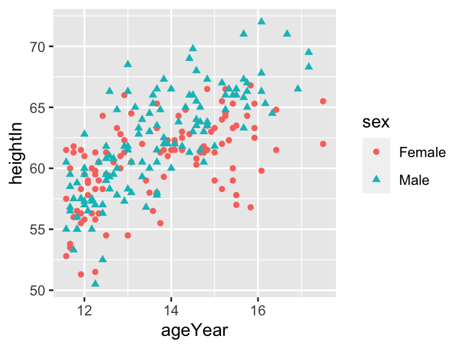

```r
p + scale_shape_discrete(labels = c('Female', 'Male')) +
  scale_color_discrete(labels = c('Female', 'Male'))
```

- 같은 변수가 shape 및 color 변수로 지정된 경우, 범례의 label을 `scale_shape_discrete()` 또는 `scale_color_discriete()` 을 통하여 바꾸는 경우에 대한 변화를 관찰할 것.